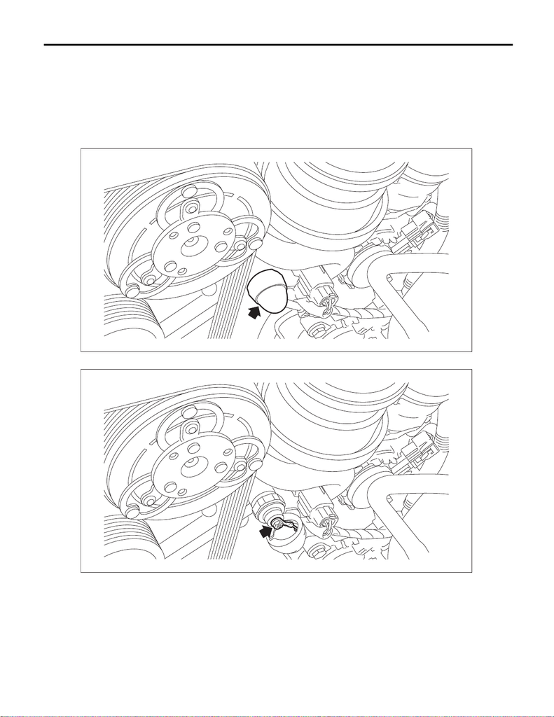

Oil Pressure Switch

LUBRICATION

6. Oil Pressure Switch

A: REMOVAL

CAUTION:

If the engine oil is spilt over exhaust pipe or the under cover, wipe it off with cloth to avoid emitting

smoke or causing a fire.

1) Disconnect the ground terminal from battery sensor. <Ref. to NT-5, BATTERY, NOTE, Note.>

2) Remove the rubber cap.

3) Disconnect the terminal from oil pressure switch.

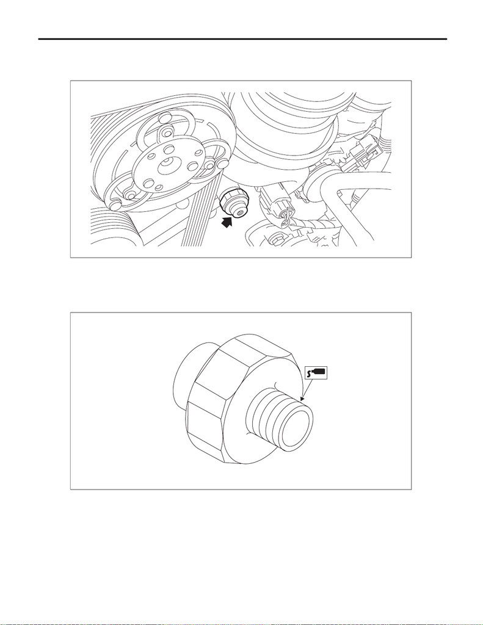

Oil Pressure Switch

LUBRICATION

4) Remove the oil pressure switch.

CAUTION:

Catch the engine oil using cloth to prevent it from splashing.

B: INSTALLATION

1) Apply liquid gasket to the oil pressure switch threads.

Liquid gasket:

THREE BOND 1324 (Part No. 004403042) or equivalent

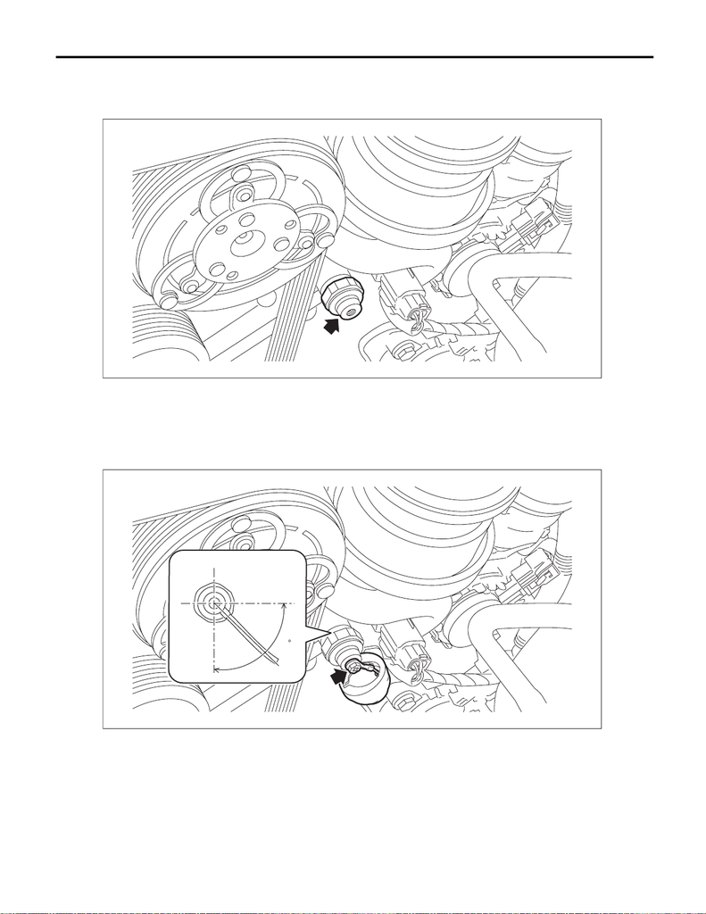

Oil Pressure Switch

LUBRICATION

2) Install the oil pressure switch to the chain cover.

Tightening torque:

18 N·m (1.8 kgf-m, 13.3 ft-lb)

3) Connect the terminal to the oil pressure switch.

NOTE:

The oil pressure switch harness must be tightened within the range of a 90° angle as shown below.

Tightening torque:

1.5 N·m (0.2 kgf-m, 1.1 ft-lb)

(A)

90

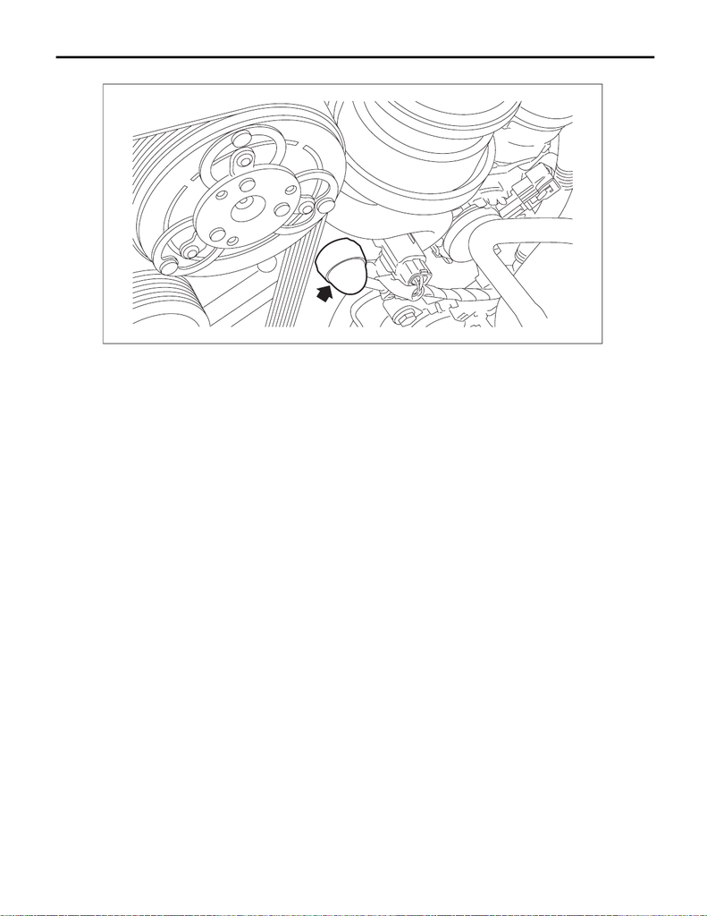

Oil Pressure Switch

LUBRICATION

4) Attach the rubber cap.

5) Connect the ground terminal to battery sensor. <Ref. to NT-5, BATTERY, NOTE, Note.>

C: INSPECTION

1) Check that the oil pressure switch does not have deformation, cracks or damage.

2) Check the oil pressure switch installation portion for oil leakage and oil seepage.